# Deep Learning

In this module, we will examine PyTorch, compare it to NumPy and examine four illustrations of Deep learning  
1. Predictive modeling with a numeric outcome using Neural Networks  
2. Predictive modeling with a categorical outcome using Neural Networks  
3. Object identification with Convolutional Neural Networks (CNNs)  
4. Transfer learning for image classification

```python
import numpy as np
import matplotlib.pyplot as plt
import seaborn as sns
from sklearn.model_selection import train_test_split
from sklearn.preprocessing import StandardScaler
from sklearn.metrics import accuracy_score, classification_report, confusion_matrix
from sklearn.datasets import fetch_california_housing, load_breast_cancer
import pandas as pd
import warnings
warnings.filterwarnings('ignore')

import torch                            # main PyTorch library for deep learning
import torch.nn as nn                   # Neural network modules (layers, activation functions, etc.)
import torch.optim as optim             # Optimization algorithms (Adam, SGD, etc.)
import torch.nn.functional as F         # Functional interface for neural network operations
from torch.utils.data import DataLoader  # Data loading utilities
from torchvision import datasets, transforms, models   # Computer vision utilities and pre-trained models


torch.manual_seed(1031)    # for reproducibility
np.random.seed(1031)       # for reproducibility
```

## PyTorch Tensors

PyTorch tensors are similar to NumPy arrays but with additional features. They can run on GPU and support automatic differentiation (gradients). The following code will highlight similarities and differences.

### Create a simple NumPy array

```python
import numpy as np
numpy_array = np.array([[1, 2, 3], [4, 5, 6]])
print("NumPy Array:")
print(numpy_array)
print(f"Type: {type(numpy_array)}")
print(f"Shape: {numpy_array.shape}")
print(f"Data type: {numpy_array.dtype}")
```

```
NumPy Array:
[[1 2 3]
 [4 5 6]]
Type: <class 'numpy.ndarray'>
Shape: (2, 3)
Data type: int64
```

### Create the same data as a PyTorch tensor

```python
torch_tensor = torch.tensor([[1, 2, 3], [4, 5, 6]])
print("\nPyTorch Tensor:")
print(torch_tensor)
print(f"Type: {type(torch_tensor)}")
print(f"Shape: {torch_tensor.shape}")
print(f"Data type: {torch_tensor.dtype}")
```

```
PyTorch Tensor:
tensor([[1, 2, 3],
        [4, 5, 6]])
Type: <class 'torch.Tensor'>
Shape: torch.Size([2, 3])
Data type: torch.int64
```

### Convert NumPy array to PyTorch tensor

```python
numpy_to_torch = torch.from_numpy(numpy_array)
print(numpy_to_torch)
```

```
tensor([[1, 2, 3],
        [4, 5, 6]])
```

### Convert PyTorch tensor to NumPy array

```python
torch_to_numpy = torch_tensor.numpy()
print(torch_to_numpy)
```

```
[[1 2 3]
 [4 5 6]]
```

### NumPy Operations

```python
numpy_result = numpy_array * 2 + 1
print("NumPy: array * 2 + 1")
print(numpy_result)
```

```
NumPy: array * 2 + 1
[[ 3  5  7]
 [ 9 11 13]]
```

### PyTorch operations (same syntax!)

```python
torch_result = torch_tensor * 2 + 1
print("\nPyTorch: tensor * 2 + 1")
print(torch_result)
```

```
PyTorch: tensor * 2 + 1
tensor([[ 3,  5,  7],
        [ 9, 11, 13]])
```

### Tensor Types

```python
float_tensor = torch.tensor([1.0, 2.0, 3.0], dtype=torch.float32)
print(float_tensor)
long_tensor = torch.tensor([1, 2, 3], dtype=torch.long)
print(long_tensor)
bool_tensor = torch.tensor([True, False, True], dtype=torch.bool)
print(bool_tensor)
```

```
tensor([1., 2., 3.])
tensor([1, 2, 3])
tensor([ True, False,  True])
```

### Tensor Dimensions

```python
tensor_1d = torch.arange(1,13)
print(tensor_1d)
```

```
tensor([ 1,  2,  3,  4,  5,  6,  7,  8,  9, 10, 11, 12])
```

```python
tensor_2d = tensor_1d.reshape(4,3)
print(tensor_2d)
```

```
tensor([[ 1,  2,  3],
        [ 4,  5,  6],
        [ 7,  8,  9],
        [10, 11, 12]])
```

```python
tensor_3d = tensor_1d.reshape(2,2,3)
print(tensor_3d)
```

```
tensor([[[ 1,  2,  3],
         [ 4,  5,  6]],

        [[ 7,  8,  9],
         [10, 11, 12]]])
```

```python
tensor_3d.flatten()
```

```
tensor([ 1,  2,  3,  4,  5,  6,  7,  8,  9, 10, 11, 12])
```

### GPU and Automatic Gradients

Two key features of PyTorch are  
- ability to leverage GPUs (if available)  
- compute automatic gradients

```python
device = torch.device('cuda' if torch.cuda.is_available() else 'cpu')
print(f"Device: {device}")
```

```
Device: cuda
```

##### Create a tensor that requires gradients

```python
x = torch.tensor([2.0], requires_grad=True)
x
```

```
tensor([2.], requires_grad=True)
```

##### Perform some operations

```python
y = x ** 2 + 3 * x + 1
y
```

```
tensor([11.], grad_fn=<AddBackward0>)
```

##### Compute gradients

```python
y.backward()
print(f"Gradient of y with respect to x: {x.grad}")
```

```
Gradient of y with respect to x: tensor([7.])
```

### Device Setup

Before, we go into applications of Deep Learning, we will setup Torch to use GPU, if available.

```python
device = torch.device('cuda' if torch.cuda.is_available() else 'cpu')
print(f"Device: {device}")
print(f"PyTorch Version: {torch.__version__}")
```

```
Device: cuda
PyTorch Version: 2.7.1+cu118
```

## Predictive modeling with a numeric outcome using Neural Networks

### Data

Use [California housing dataset](https://scikit-learn.org/stable/datasets/real_world.html#california-housing-dataset) to predict average house price of a block group using income, age, rooms, bedrooms, population, number of household members, latitude and longitude.

```python
california = fetch_california_housing()
X_california = california.data  # features
y_california = california.target  # outcome variable (house price)
```

### Split the Data

```python
X_train_california, X_test_california, y_train_california, y_test_california = train_test_split(X_california,
                                                                                                y_california,
                                                                                                test_size=0.2,
                                                                                                random_state=617)
```

### Standardize Features

```python
scale_california = StandardScaler()
X_train_california_scaled = scale_california.fit_transform(X_train_california)
X_test_california_scaled = scale_california.transform(X_test_california)
```

### Convert NumPy Arrays to PyTorch Tensors

```python
X_train_california_tensor = torch.FloatTensor(X_train_california_scaled).to(device)
y_train_california_tensor = torch.FloatTensor(y_train_california).to(device)
X_test_california_tensor = torch.FloatTensor(X_test_california_scaled).to(device)
y_test_california_tensor = torch.FloatTensor(y_test_california).to(device)
```

### Create Neural Network

Use nn.Sequential()

```python
regression_model = nn.Sequential(
    nn.Linear(8, 64),       # Input layer: 8 features to 64 neurons
    nn.ReLU(),              # Activation function: introduces non-linearity
    nn.Dropout(0.2),        # Dropout: prevents overfitting by randomly setting 20% of neurons to 0
    nn.Linear(64, 32),      # Hidden layer: 64 to 32 neurons
    nn.ReLU(),              # Activation function
    nn.Dropout(0.2),        # Dropout for regularization
    nn.Linear(32, 16),      # Hidden layer: 32 to16 neurons
    nn.ReLU(),              # Activation function
    nn.Dropout(0.2),        # Dropout for regularization
    nn.Linear(16, 1)        # Output layer: 16 to 1 neuron (house price prediction)
).to(device)
print(regression_model)
```

```
Sequential(
  (0): Linear(in_features=8, out_features=64, bias=True)
  (1): ReLU()
  (2): Dropout(p=0.2, inplace=False)
  (3): Linear(in_features=64, out_features=32, bias=True)
  (4): ReLU()
  (5): Dropout(p=0.2, inplace=False)
  (6): Linear(in_features=32, out_features=16, bias=True)
  (7): ReLU()
  (8): Dropout(p=0.2, inplace=False)
  (9): Linear(in_features=16, out_features=1, bias=True)
)
```

### Loss Function

- Use MSE for measuring model error
- Adam Optimizer to update model parameters
- Set learning rate to 0.001

```python
criterion = nn.MSELoss()
optimizer = optim.Adam(regression_model.parameters(), lr=0.001)
```

### Epochs

Repeat the process many times (epochs) to improve the model

```python
train_losses = []
for epoch in range(100):
    # Set model to training mode (enables dropout, batch normalization, etc.)
    regression_model.train()

    # Zero the gradients (PyTorch accumulates gradients, so we need to reset them)
    optimizer.zero_grad()

    # Forward pass: compute predictions
    predictions = regression_model(X_train_california_tensor).squeeze()
    loss = criterion(predictions, y_train_california_tensor)

    # Backward pass: compute gradients
    loss.backward()

    # Update parameters using the optimizer
    optimizer.step()

    # Store loss for plotting
    train_losses.append(loss.item())

    # Print progress every 20 epochs
    if (epoch + 1) % 20 == 0:
        print(f'Epoch [{epoch+1:3d}/100], Loss: {loss.item():.4f}')
```

```
Epoch [ 20/100], Loss: 4.2713
Epoch [ 40/100], Loss: 2.1136
Epoch [ 60/100], Loss: 1.4547
Epoch [ 80/100], Loss: 1.1500
Epoch [100/100], Loss: 1.0118
```

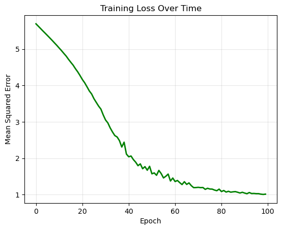

```python
plt.plot(train_losses, color='green', linewidth=2)
plt.xlabel('Epoch')
plt.ylabel('Mean Squared Error')
plt.title('Training Loss Over Time')
plt.grid(True, alpha=0.3)
plt.show()
```

### Model Evaluation

- Evaluation mode disables dropout and other training-specific behaviors.
- torch.no_grad() saves memory by not computing gradients during evaluation

```python
regression_model.eval()
with torch.no_grad():
    test_predictions = regression_model(X_test_california_tensor).squeeze()
    mse = F.mse_loss(test_predictions, y_test_california_tensor)

print(f"\nRegression Results:")
print(f"Mean Squared Error (MSE): {mse.item():.4f}")
```

```
Regression Results:
Mean Squared Error (MSE): 0.7311
```

## Predictive modeling with a categorical outcome using Neural Networks

### Data

Use [Breast Cancer dataset](https://scikit-learn.org/stable/datasets/toy_dataset.html#breast-cancer-dataset) to predict type of cancer (benign or malignant) based on tumor characteristics.

```python
cancer = load_breast_cancer()
X_cancer = cancer.data    # Predictors (tumor characteristics)
y_cancer = cancer.target  # Outcome (0=malignant, 1=benign)
```

### Split the Data

```python
X_train_cancer, X_test_cancer, y_train_cancer, y_test_cancer = train_test_split(X_cancer,
                                                                                y_cancer,
                                                                                test_size=0.2,
                                                                                random_state=617,
                                                                                stratify=y_cancer)
```

### Standardize Features

```python
scale_cancer = StandardScaler()
X_train_cancer_scaled = scale_cancer.fit_transform(X_train_cancer)
X_test_cancer_scaled = scale_cancer.transform(X_test_cancer)
```

### Convert NumPy Arrays to PyTorch Tensors

```python
X_train_cancer_tensor = torch.FloatTensor(X_train_cancer_scaled).to(device)
y_train_cancer_tensor = torch.LongTensor(y_train_cancer).to(device)  # LongTensor for classification labels
X_test_cancer_tensor = torch.FloatTensor(X_test_cancer_scaled).to(device)
y_test_cancer_tensor = torch.LongTensor(y_test_cancer).to(device)
```

### Create Neural Network

Use nn.Sequential(). Unlike regression, there are two output neurons, one to represent each category of outcome.

```python
classification_model = nn.Sequential(
    nn.Linear(30, 64),      # Input layer: 30 features to 64 neurons
    nn.ReLU(),              # Activation function
    nn.Dropout(0.3),        # Dropout: prevents overfitting
    nn.Linear(64, 32),      # Hidden layer: 64 to 32 neurons
    nn.ReLU(),              # Activation function
    nn.Dropout(0.3),        # Dropout for regularization
    nn.Linear(32, 2)        # Output layer: 32 to 2 neurons (binary classification)
).to(device)
print(classification_model)
```

```
Sequential(
  (0): Linear(in_features=30, out_features=64, bias=True)
  (1): ReLU()
  (2): Dropout(p=0.3, inplace=False)
  (3): Linear(in_features=64, out_features=32, bias=True)
  (4): ReLU()
  (5): Dropout(p=0.3, inplace=False)
  (6): Linear(in_features=32, out_features=2, bias=True)
)
```

### Loss Function

- Use Cross Entropy Loss for loss function. This combines softmax activation with negative log likelihood.
- Adam Optimizer to update model parameters
- Set learning rate to 0.001

```python
criterion = nn.CrossEntropyLoss()
optimizer = optim.Adam(classification_model.parameters(), lr=0.001)
```

### Epochs

```python
train_losses = []
train_accuracies = []

for epoch in range(100):
    classification_model.train()
    optimizer.zero_grad()

    # Forward pass
    outputs = classification_model(X_train_cancer_tensor)
    loss = criterion(outputs, y_train_cancer_tensor)

    # Backward pass and optimization
    loss.backward()
    optimizer.step()

    # Computing accuracy because it is more relateable for a classification problem
    # We use torch.max to get the predicted class (highest score)
    _, predicted = torch.max(outputs.data, 1)
    accuracy = (predicted == y_train_cancer_tensor).sum().item() / y_train_cancer_tensor.size(0)

    # Store metrics for plotting
    train_losses.append(loss.item())
    train_accuracies.append(accuracy)

    # Print progress every 20 epochs
    if (epoch + 1) % 20 == 0:
        print(f'Epoch [{epoch+1:3d}/100], Loss: {loss.item():.4f}, Accuracy: {accuracy:.4f}')
```

```
Epoch [ 20/100], Loss: 0.4376, Accuracy: 0.9275
Epoch [ 40/100], Loss: 0.1871, Accuracy: 0.9516
Epoch [ 60/100], Loss: 0.0957, Accuracy: 0.9670
Epoch [ 80/100], Loss: 0.0689, Accuracy: 0.9824
Epoch [100/100], Loss: 0.0474, Accuracy: 0.9868
```

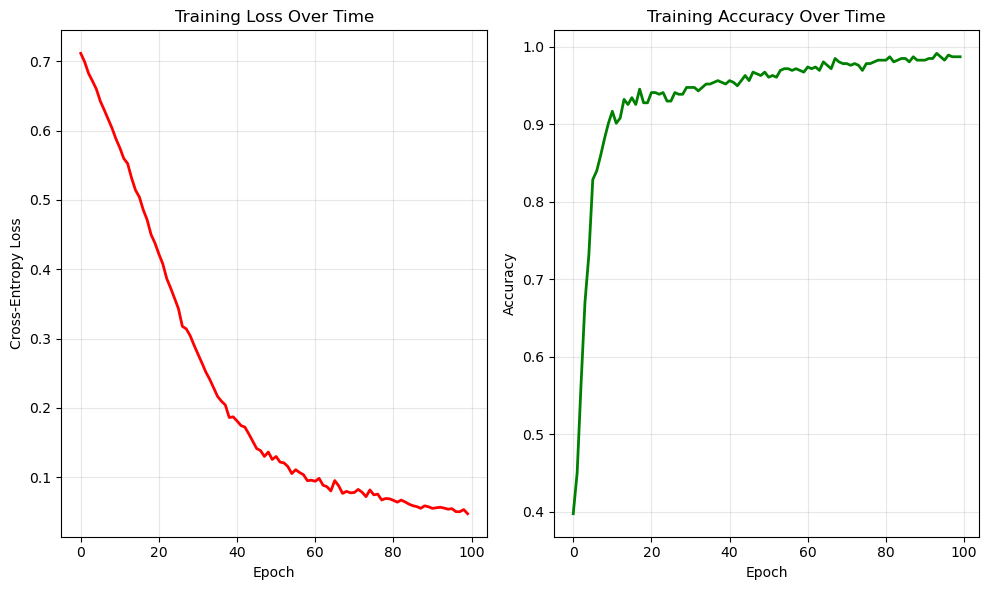

```python
fig, (ax1, ax2) = plt.subplots(1, 2, figsize=(10, 6))

# Plot 1: Training loss
ax1.plot(train_losses, color='red', linewidth=2)
ax1.set_xlabel('Epoch')
ax1.set_ylabel('Cross-Entropy Loss')
ax1.set_title('Training Loss Over Time')
ax1.grid(True, alpha=0.3)

# Plot 2: Training accuracy
ax2.plot(train_accuracies, color='green', linewidth=2)
ax2.set_xlabel('Epoch')
ax2.set_ylabel('Accuracy')
ax2.set_title('Training Accuracy Over Time')
ax2.grid(True, alpha=0.3)

plt.tight_layout()
plt.show()
```

### Model Evaluation

```python
classification_model.eval()
with torch.no_grad():
    test_outputs = classification_model(X_test_cancer_tensor)
    _, test_predictions = torch.max(test_outputs, 1)

    # Calculate accuracy
    test_accuracy = accuracy_score(y_test_cancer_tensor.cpu().numpy(),
                                 test_predictions.cpu().numpy())

print(f"\nClassification Results:")
print(f"Test Accuracy: {test_accuracy:.4f}")
print(classification_report(y_test_cancer_tensor.cpu().numpy(),
                          test_predictions.cpu().numpy(),
                          target_names=cancer.target_names))
```

```
Classification Results:
Test Accuracy: 0.9737
              precision    recall  f1-score   support

   malignant       1.00      0.93      0.96        42
      benign       0.96      1.00      0.98        72

    accuracy                           0.97       114
   macro avg       0.98      0.96      0.97       114
weighted avg       0.97      0.97      0.97       114
```

```python
cm = confusion_matrix(y_test_cancer_tensor.cpu().numpy(),
                      test_predictions.cpu().numpy())
cm
```

```
array([[39,  3],
       [ 0, 72]])
```

## Object identification with Convolutional Neural Networks (CNNs)

CNNs are specialized for processing grid-like data (images). They use convolutional layers to detect patterns like edges, textures, shapes. This is much more effective than fully connected layers for images

### Data

The [CIFAR-10 dataset](https://www.cs.toronto.edu/~kriz/cifar.html) consists of 60000 32x32 colour images in 10 classes, with 6000 images per class. There are 50000 training images and 10000 test images. This is a standard image classification dataset.

### Data Augmentation and Loading Data

Data augmentation creates variations of training images. This helps prevent overfitting and improves generalization. We only augment training data, not test data

```python
transform_train = transforms.Compose([
    transforms.RandomHorizontalFlip(),    # Random horizontal flip for augmentation
    transforms.RandomRotation(10),        # Random rotation up to 10 degrees
    transforms.ColorJitter(brightness=0.2, contrast=0.2, saturation=0.2),  # Color augmentation
    transforms.ToTensor(),                # Convert to tensor
    transforms.Normalize((0.4914, 0.4822, 0.4465), (0.2023, 0.1994, 0.2010))  # Normalize
])

transform_test = transforms.Compose([
    transforms.ToTensor(),                # Convert to tensor
    transforms.Normalize((0.4914, 0.4822, 0.4465), (0.2023, 0.1994, 0.2010))  # Normalize
])

trainset = datasets.CIFAR10(root='./data', train=True, download=True, transform=transform_train)
testset = datasets.CIFAR10(root='./data', train=False, download=True, transform=transform_test)
```

### Data Loader

DataLoader handles batching, shuffling, and parallel loading. Batch size of 64 means we process 64 images at once. This is more efficient than processing one image at a time

```python
trainloader = DataLoader(trainset, batch_size=64, shuffle=True, num_workers=2)
testloader = DataLoader(testset, batch_size=64, shuffle=False, num_workers=2)

# Class names for CIFAR-10
classes = ('airplane', 'automobile', 'bird', 'cat', 'deer',
          'dog', 'frog', 'horse', 'ship', 'truck')

print("Dataset Information:")
print(f"Training samples: {len(trainset)}")
print(f"Test samples: {len(testset)}")
print(f"Number of classes: {len(classes)}")
print(f"Image size: 32x32 pixels")
print(f"Classes: {classes}")
```

```
Dataset Information:
Training samples: 50000
Test samples: 10000
Number of classes: 10
Image size: 32x32 pixels
Classes: ('airplane', 'automobile', 'bird', 'cat', 'deer', 'dog', 'frog', 'horse', 'ship', 'truck')
```

### Sample images from the dataset

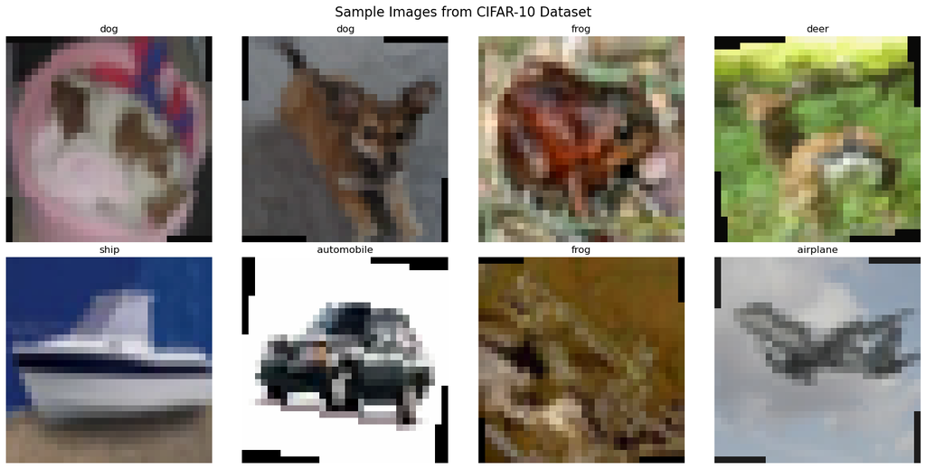

```python
dataiter = iter(trainloader)
images, labels = next(dataiter)

fig, axes = plt.subplots(2, 4, figsize=(16, 8))
for i in range(8):
    row, col = i // 4, i % 4
    img = images[i].numpy().transpose((1, 2, 0))
    # We need to denormalize images for display
    # The normalization values are specific to CIFAR-10
    img = img * np.array([0.2023, 0.1994, 0.2010]) + np.array([0.4914, 0.4822, 0.4465])
    img = np.clip(img, 0, 1)

    axes[row, col].imshow(img)
    axes[row, col].set_title(f'{classes[labels[i]]}', fontsize=12)
    axes[row, col].axis('off')

plt.suptitle('Sample Images from CIFAR-10 Dataset', fontsize=16)
plt.tight_layout()
plt.show()
```

### CNN architecture

CNN architecture follows a pattern: 1. Convolutional layers (detect features) 2. Pooling layers (reduce spatial dimensions) 3. Fully connected layers (make final predictions)

```python
cnn_model = nn.Sequential(
    # First convolutional block
    # Conv2d parameters: (input_channels, output_channels, kernel_size, padding)
    nn.Conv2d(3, 32, 3, padding=1),    # 3 input channels to 32 output channels, 3x3 kernel
    nn.ReLU(),                         # Activation function
    nn.MaxPool2d(2, 2),                # 2x2 max pooling: 32x32 to 16x16

    # Second convolutional block
    nn.Conv2d(32, 64, 3, padding=1),   # 32 input channels to 64 output channels, 3x3 kernel
    nn.ReLU(),                         # Activation function
    nn.MaxPool2d(2, 2),                # 2x2 max pooling: 16x16 to 8x8

    # Third convolutional block
    nn.Conv2d(64, 128, 3, padding=1),  # 64 input channels to 128 output channels, 3x3 kernel
    nn.ReLU(),                         # Activation function
    nn.MaxPool2d(2, 2),                # 2x2 max pooling: 8x8 to 4x4

    # Flatten converts 2D feature maps to 1D vectorto  connect to fully connected layers
    nn.Flatten(),                      # Flatten 128*4*4 = 2048 features

    # Fully connected layers
    nn.Linear(128 * 4 * 4, 512),       # 2048 to 512 neurons
    nn.ReLU(),                         # Activation function
    nn.Dropout(0.25),                  # Dropout for regularization
    nn.Linear(512, 10)                 # 512 to 10 neurons (10 classes)
).to(device)

print(cnn_model)
```

```
Sequential(
  (0): Conv2d(3, 32, kernel_size=(3, 3), stride=(1, 1), padding=(1, 1))
  (1): ReLU()
  (2): MaxPool2d(kernel_size=2, stride=2, padding=0, dilation=1, ceil_mode=False)
  (3): Conv2d(32, 64, kernel_size=(3, 3), stride=(1, 1), padding=(1, 1))
  (4): ReLU()
  (5): MaxPool2d(kernel_size=2, stride=2, padding=0, dilation=1, ceil_mode=False)
  (6): Conv2d(64, 128, kernel_size=(3, 3), stride=(1, 1), padding=(1, 1))
  (7): ReLU()
  (8): MaxPool2d(kernel_size=2, stride=2, padding=0, dilation=1, ceil_mode=False)
  (9): Flatten(start_dim=1, end_dim=-1)
  (10): Linear(in_features=2048, out_features=512, bias=True)
  (11): ReLU()
  (12): Dropout(p=0.25, inplace=False)
  (13): Linear(in_features=512, out_features=10, bias=True)
)
```

#### Model Parameters

```python
total_params = sum(p.numel() for p in cnn_model.parameters())
#trainable_params = sum(p.numel() for p in cnn_model.parameters() if p.requires_grad)
print(f"\nModel Statistics:")
print(f"Total parameters: {total_params:,}")
#print(f"Trainable parameters: {trainable_params:,}")
```

```
Model Statistics:
Total parameters: 1,147,466
```

### Training the CNN

#### Learning rate scheduler

Learning rate scheduler reduces learning rate over time. This helps the model converge to better solutions

```python
criterion = nn.CrossEntropyLoss()
optimizer = optim.Adam(cnn_model.parameters(), lr=0.001)
scheduler = optim.lr_scheduler.StepLR(optimizer, step_size=7, gamma=0.1)
```

#### Training loop

Training with batches is more efficient than individual samples

```python
train_losses = []
train_accuracies = []

for epoch in range(5):  # Reduced epochs for faster execution
    cnn_model.train()
    running_loss = 0.0
    correct = 0
    total = 0

    for batch_idx, data in enumerate(trainloader, 0):
        inputs, labels = data[0].to(device), data[1].to(device)

        # Zero the gradients
        optimizer.zero_grad()

        # Forward pass
        outputs = cnn_model(inputs)
        loss = criterion(outputs, labels)

        # Backward pass and optimization
        loss.backward()
        optimizer.step()

        # Calculate accuracy
        _, predicted = torch.max(outputs.data, 1)
        total += labels.size(0)
        correct += (predicted == labels).sum().item()

        running_loss += loss.item()

        # Print progress every 100 batches
        if batch_idx % 100 == 99:
            print(f'[{epoch + 1}, {batch_idx + 1:5d}] Loss: {running_loss / 100:.3f}')
            running_loss = 0.0

    # Update learning rate
    scheduler.step()

    # Calculate epoch metrics
    epoch_loss = running_loss / len(trainloader)
    epoch_accuracy = 100 * correct / total
    train_losses.append(epoch_loss)
    train_accuracies.append(epoch_accuracy)

    print(f'Epoch {epoch+1}/5 - Loss: {epoch_loss:.4f}, Accuracy: {epoch_accuracy:.2f}%')
```

```
[1,   100] Loss: 1.917
[1,   200] Loss: 1.544
[1,   300] Loss: 1.446
[1,   400] Loss: 1.362
[1,   500] Loss: 1.294
[1,   600] Loss: 1.237
[1,   700] Loss: 1.214
[2,   100] Loss: 1.112
[2,   200] Loss: 1.099
[2,   300] Loss: 1.044
[2,   400] Loss: 0.993
[2,   500] Loss: 0.975
[2,   600] Loss: 0.979
[2,   700] Loss: 0.989
[3,   100] Loss: 0.921
```

[output cut: 20 more lines]

### Evaluating the CNN

Per-class accuracy helps identify which classes are harder to predict. This can guide improvements to the model.

```python
cnn_model.eval()
correct = 0
total = 0
class_correct = list(0. for i in range(10))
class_total = list(0. for i in range(10))

with torch.no_grad():
    for data in testloader:
        images, labels = data[0].to(device), data[1].to(device)
        outputs = cnn_model(images)
        _, predicted = torch.max(outputs, 1)

        total += labels.size(0)
        correct += (predicted == labels).sum().item()

        # Calculate per-class accuracy
        c = (predicted == labels).squeeze()
        for i in range(len(labels)):
            label = labels[i]
            class_correct[label] += c[i].item()
            class_total[label] += 1

# Print results
cnn_accuracy = 100 * correct / total
print(f'Overall Test Accuracy: {cnn_accuracy:.2f}%')
print(f'\nPer-Class Accuracy:')
for i in range(10):
    print(f'{classes[i]:12s}: {100 * class_correct[i] / class_total[i]:.2f}%')
```

```
Overall Test Accuracy: 75.20%

Per-Class Accuracy:
airplane    : 74.90%
automobile  : 86.40%
bird        : 71.40%
cat         : 52.70%
deer        : 63.90%
dog         : 57.10%
frog        : 90.30%
horse       : 83.10%
ship        : 92.50%
truck       : 79.70%
```

#### Visualize predictions

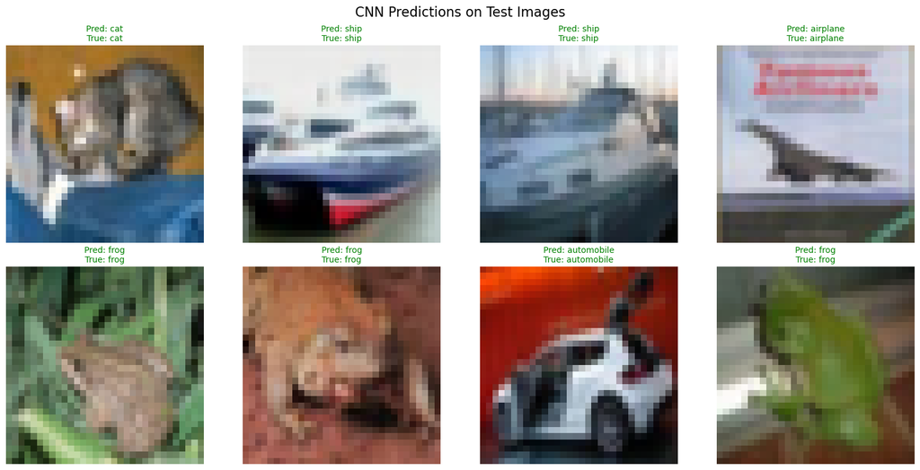

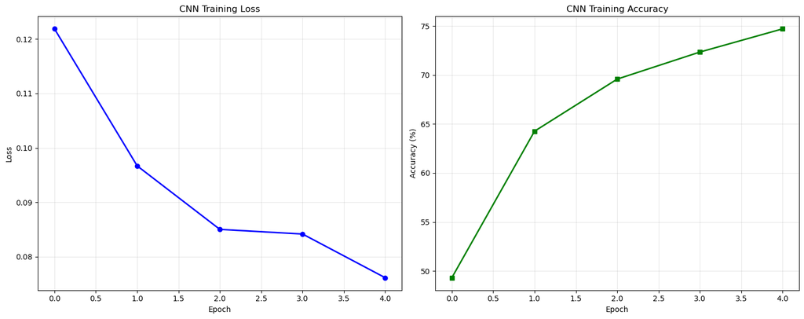

```python
dataiter = iter(testloader)
images, labels = next(dataiter)
images = images[:8].to(device)
labels = labels[:8]

outputs = cnn_model(images)
_, predicted = torch.max(outputs, 1)

fig, axes = plt.subplots(2, 4, figsize=(16, 8))
for i in range(8):
    row, col = i // 4, i % 4
    img = images[i].cpu().numpy().transpose((1, 2, 0))
    # Denormalize the image
    img = img * np.array([0.2023, 0.1994, 0.2010]) + np.array([0.4914, 0.4822, 0.4465])
    img = np.clip(img, 0, 1)

    axes[row, col].imshow(img)
    title = f'Pred: {classes[predicted[i]]}\nTrue: {classes[labels[i]]}'
    color = 'green' if predicted[i] == labels[i] else 'red'
    axes[row, col].set_title(title, color=color, fontsize=10)
    axes[row, col].axis('off')

plt.suptitle('CNN Predictions on Test Images', fontsize=16)
plt.tight_layout()
plt.show()

# Plot training metrics
fig, (ax1, ax2) = plt.subplots(1, 2, figsize=(15, 6))

ax1.plot(train_losses, color='blue', linewidth=2, marker='o')
ax1.set_xlabel('Epoch')
ax1.set_ylabel('Loss')
ax1.set_title('CNN Training Loss')
ax1.grid(True, alpha=0.3)

ax2.plot(train_accuracies, color='green', linewidth=2, marker='s')
ax2.set_xlabel('Epoch')
ax2.set_ylabel('Accuracy (%)')
ax2.set_title('CNN Training Accuracy')
ax2.grid(True, alpha=0.3)

plt.tight_layout()
plt.show()
```

## Transfer learning for image classification

Transfer learning uses pre-trained models on new tasks. This is much more efficient than training from scratch. The pre-trained model has already learned useful features from a large dataset.

### Pre-Trained Model

ResNet18 is a powerful CNN architecture pre-trained on ImageNet. ImageNet has 1.2 million images in 1000 classes. The model has learned to recognize general visual features

### Load pre-trained model

```python
transfer_model = models.resnet18(pretrained=True)
```

#### Freeze Pre-trained layers

We freeze the pre-trained layers to preserve their learned features. We only train the final classification layer for our specific task.

```python
for param in transfer_model.parameters():
    param.requires_grad = False
```

#### Model

We replace the final layer to match our number of classes. ResNet18 was trained for 1000 classes, but CIFAR-10 has only 10

```python
num_ftrs = transfer_model.fc.in_features
transfer_model.fc = nn.Linear(num_ftrs, 10  # Simple linear layer for 10 classes.
                                             # It is possible to unfreeze last few layers and train them by adding layers here.
                             )
transfer_model = transfer_model.to(device)
```

#### Unfreeze the last layer

We need to unfreeze the final layer after replacing it. The new final layer parameters should be trainable.

```python
transfer_model.fc.requires_grad_(True)
```

```
Linear(in_features=512, out_features=10, bias=True)
```

#### Transfer Model Architecture

```python
print(transfer_model)
```

```
ResNet(
  (conv1): Conv2d(3, 64, kernel_size=(7, 7), stride=(2, 2), padding=(3, 3), bias=False)
  (bn1): BatchNorm2d(64, eps=1e-05, momentum=0.1, affine=True, track_running_stats=True)
  (relu): ReLU(inplace=True)
  (maxpool): MaxPool2d(kernel_size=3, stride=2, padding=1, dilation=1, ceil_mode=False)
  (layer1): Sequential(
    (0): BasicBlock(
      (conv1): Conv2d(64, 64, kernel_size=(3, 3), stride=(1, 1), padding=(1, 1), bias=False)
      (bn1): BatchNorm2d(64, eps=1e-05, momentum=0.1, affine=True, track_running_stats=True)
      (relu): ReLU(inplace=True)
      (conv2): Conv2d(64, 64, kernel_size=(3, 3), stride=(1, 1), padding=(1, 1), bias=False)
      (bn2): BatchNorm2d(64, eps=1e-05, momentum=0.1, affine=True, track_running_stats=True)
    )
    (1): BasicBlock(
      (conv1): Conv2d(64, 64, kernel_size=(3, 3), stride=(1, 1), padding=(1, 1), bias=False)
      (bn1): BatchNorm2d(64, eps=1e-05, momentum=0.1, affine=True, track_running_stats=True)
      (relu): ReLU(inplace=True)
      (conv2): Conv2d(64, 64, kernel_size=(3, 3), stride=(1, 1), padding=(1, 1), bias=False)
      (bn2): BatchNorm2d(64, eps=1e-05, momentum=0.1, affine=True, track_running_stats=True)
    )
  )
  (layer2): Sequential(
    (0): BasicBlock(
      (conv1): Conv2d(64, 128, kernel_size=(3, 3), stride=(2, 2), padding=(1, 1), bias=False)
      (bn1): BatchNorm2d(128, eps=1e-05, momentum=0.1, affine=True, track_running_stats=True)
      (relu): ReLU(inplace=True)
      (conv2): Conv2d(128, 128, kernel_size=(3, 3), stride=(1, 1), padding=(1, 1), bias=False)
      (bn2): BatchNorm2d(128, eps=1e-05, momentum=0.1, affine=True, track_running_stats=True)
      (downsample): Sequential(
        (0): Conv2d(64, 128, kernel_size=(1, 1), stride=(2, 2), bias=False)
        (1): BatchNorm2d(128, eps=1e-05, momentum=0.1, affine=True, track_running_stats=True)
      )
    )
    (1): BasicBlock(
      (conv1): Conv2d(128, 128, kernel_size=(3, 3), stride=(1, 1), padding=(1, 1), bias=False)
      (bn1): BatchNorm2d(128, eps=1e-05, momentum=0.1, affine=True, track_running_stats=True)
      (relu): ReLU(inplace=True)
      (conv2): Conv2d(128, 128, kernel_size=(3, 3), stride=(1, 1), padding=(1, 1), bias=False)
      (bn2): BatchNorm2d(128, eps=1e-05, momentum=0.1, affine=True, track_running_stats=True)
    )
```

[output cut: 29 more lines]

```
        (0): Conv2d(256, 512, kernel_size=(1, 1), stride=(2, 2), bias=False)
        (1): BatchNorm2d(512, eps=1e-05, momentum=0.1, affine=True, track_running_stats=True)
      )
    )
    (1): BasicBlock(
      (conv1): Conv2d(512, 512, kernel_size=(3, 3), stride=(1, 1), padding=(1, 1), bias=False)
      (bn1): BatchNorm2d(512, eps=1e-05, momentum=0.1, affine=True, track_running_stats=True)
      (relu): ReLU(inplace=True)
      (conv2): Conv2d(512, 512, kernel_size=(3, 3), stride=(1, 1), padding=(1, 1), bias=False)
      (bn2): BatchNorm2d(512, eps=1e-05, momentum=0.1, affine=True, track_running_stats=True)
    )
  )
  (avgpool): AdaptiveAvgPool2d(output_size=(1, 1))
  (fc): Linear(in_features=512, out_features=10, bias=True)
)
```

#### Count Parameters

After freezing layers, only the final layer parameters are trainable. This is the key advantage of transfer learning - we reuse pre-trained features

```python
total_params = sum(p.numel() for p in transfer_model.parameters())
trainable_params = sum(p.numel() for p in transfer_model.parameters() if p.requires_grad)
frozen_params = total_params - trainable_params

print(f"\nTransfer Learning Model Characteristics:")
print(f"Total parameters: {total_params:,}")
print(f"Frozen parameters: {frozen_params:,} (pre-trained layers)")
print(f"Trainable parameters: {trainable_params:,} (new final layer)")
print(f"Parameter efficiency: {trainable_params/total_params:.2%}")

print(f"\nBreakdown:")
print(f"  - Pre-trained ResNet18 layers: {frozen_params:,} parameters (frozen)")
print(f"  - New final classification layer: {trainable_params:,} parameters (trainable)")
```

```
Transfer Learning Model Characteristics:
Total parameters: 11,181,642
Frozen parameters: 11,176,512 (pre-trained layers)
Trainable parameters: 5,130 (new final layer)
Parameter efficiency: 0.05%

Breakdown:
  - Pre-trained ResNet18 layers: 11,176,512 parameters (frozen)
  - New final classification layer: 5,130 parameters (trainable)
```

### Train Transfer Learning Model

We only optimize the final layer parameters. This is much faster than training the entire network.

```python
criterion = nn.CrossEntropyLoss()
optimizer = optim.Adam(transfer_model.fc.parameters(), lr=0.001)

print(f"Training only the final layer with {sum(p.numel() for p in transfer_model.fc.parameters())} parameters")

for epoch in range(5):  # Fewer epochs since we're only training one layer
    transfer_model.train()
    running_loss = 0.0

    for batch_idx, data in enumerate(trainloader, 0):
        inputs, labels = data[0].to(device), data[1].to(device)

        # Zero the gradients
        optimizer.zero_grad()

        # Forward pass
        outputs = transfer_model(inputs)
        loss = criterion(outputs, labels)

        # Backward pass and optimization
        loss.backward()
        optimizer.step()

        running_loss += loss.item()

        # Print progress every 100 batches
        if batch_idx % 100 == 99:
            print(f'[{epoch + 1}, {batch_idx + 1:5d}] Loss: {running_loss / 100:.3f}')
            running_loss = 0.0

    # Print epoch summary
    epoch_loss = running_loss / len(trainloader)
    print(f'Epoch {epoch+1}/5 - Average Loss: {epoch_loss:.4f}')
```

```
Training only the final layer with 5130 parameters
[1,   100] Loss: 2.146
[1,   200] Loss: 1.931
[1,   300] Loss: 1.831
[1,   400] Loss: 1.821
[1,   500] Loss: 1.801
[1,   600] Loss: 1.784
[1,   700] Loss: 1.781
[2,   100] Loss: 1.755
[2,   200] Loss: 1.741
[2,   300] Loss: 1.779
[2,   400] Loss: 1.738
[2,   500] Loss: 1.732
[2,   600] Loss: 1.741
[2,   700] Loss: 1.762
```

[output cut: 21 more lines]

### Evaluate Transfer Learning

Transfer learning often achieves better performance with less training.

```python
transfer_model.eval()
correct = 0
total = 0

with torch.no_grad():
    for data in testloader:
        images, labels = data[0].to(device), data[1].to(device)
        outputs = transfer_model(images)
        _, predicted = torch.max(outputs, 1)
        total += labels.size(0)
        correct += (predicted == labels).sum().item()

transfer_accuracy = 100 * correct / total
print(f"Transfer Learning Test Accuracy: {transfer_accuracy:.2f}%")
```

```
Transfer Learning Test Accuracy: 42.28%
```

#### Transfer Learning vs. CNN

Transfer Learning Test Accuracy fell short of the CNN Test Accuracy. This may be because of differences in the domain of ResNet images from those in CIFAR-10 or the small relative size. In such situations, the transfer learning model will need fine tuning of some pre-trained layers.

```python
print(f'CNN Test Accuracy: {cnn_accuracy:.2f}%')
```

```
CNN Test Accuracy: 75.20%
```

## Summary

In this module, we examined PyTorch, compared it to NumPy and examined four illustrations of Deep learning

1. Predictive modeling with a numeric outcome using Neural Networks
2. Predictive modeling with a categorical outcome using Neural Networks
3. Object identification with Convolutional Neural Networks (CNNs)
4. Transfer learning for image classification

This file was generated using Python 3.11.13 on Windows 10 with the following libraries: matplotlib 3.10.0, numpy 2.0.1, pandas 2.2.3, scikit-learn 1.6.1, seaborn 0.13.2, torch 2.7.1+cu118, torchvision 0.22.1+cu118